# 推文波峰报告

Kang

2022-12-17

原数据中，每天的推文强度跟90%、85%、80%、75%分位推文强度高值的比较如下图。有些波峰特别高，为了方便查看，对纵轴取了对数。反正这个图没什么动用就是了，看看就好了。

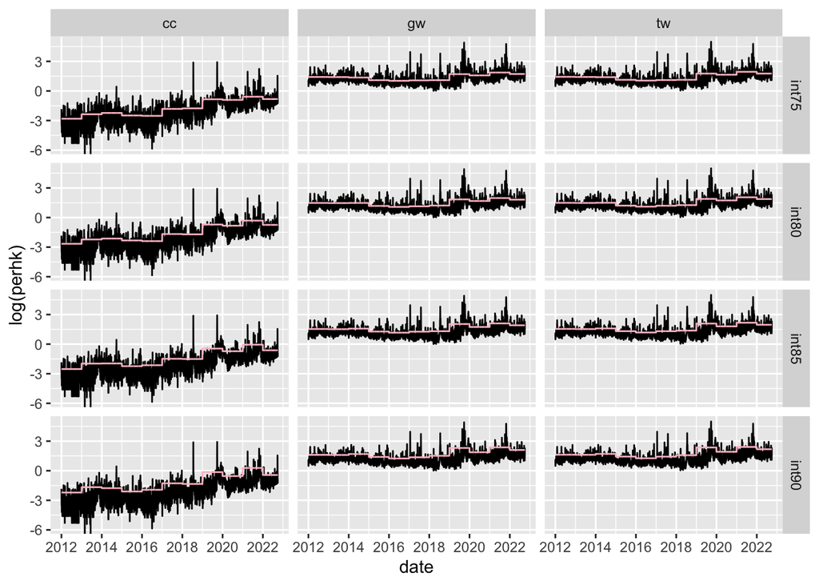

再计算这些口径下，不同分位数情况下，高值日期推文数的条数，和占总各口径总推文数比例。条数为：

| int_idx | cc | gw | tw |
| --- | --- | --- | --- |
| int75 | 255921 | 3230100 | 3368526 |
| int80 | 232485 | 2873715 | 2990425 |
| int85 | 204904 | 2475893 | 2570806 |
| int90 | 169731 | 2020037 | 2094429 |

比例为：

| int_idx | cc | gw | tw |
| --- | --- | --- | --- |
| int75 | 0.5835977 | 0.4804194 | 0.4789100 |
| int80 | 0.5301546 | 0.4274135 | 0.4251546 |
| int85 | 0.4672594 | 0.3682447 | 0.3654966 |
| int90 | 0.3870515 | 0.3004443 | 0.2977691 |

```
##
##       3  4  5  6  7  8  9 10 11 13 14 15
##   cc 12  8  4  5  0  2  2  0  1  1  0  0
##   gw 14  7  9  3  2  2  1  1  1  1  1  0
##   tw 12  7  9  2  3  2  2  0  1  1  0  1
```

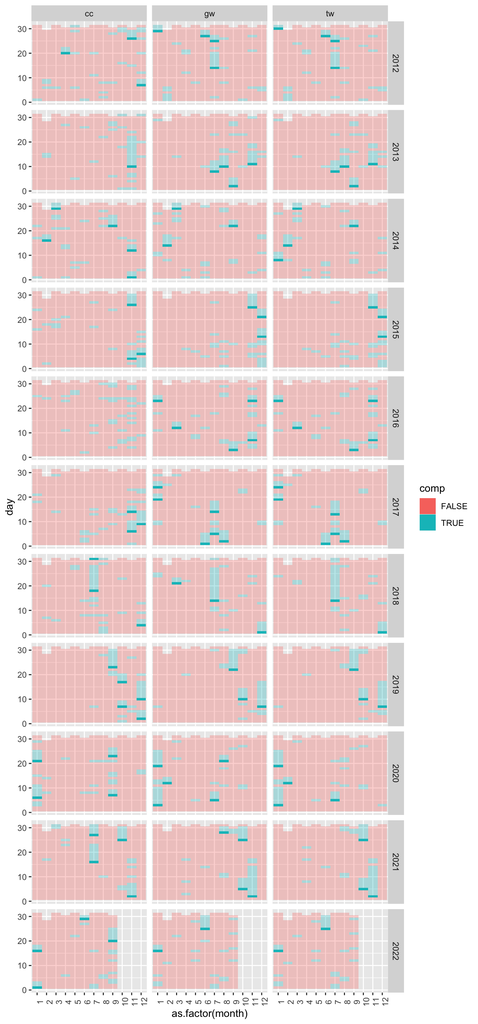

上图对应的数据为，其中“TRUE”为该口径下该日期为高值起点日期：

| date | cc | gw | tw | tw_gw_cc | tw_gw | tw_cc | gw_gw |
| --- | --- | --- | --- | --- | --- | --- | --- |
| 2012-04-20 | TRUE | NA | NA | NA | NA | NA | NA |
| 2012-11-26 | TRUE | NA | NA | NA | NA | NA | NA |
| 2012-12-07 | TRUE | NA | NA | NA | NA | NA | NA |
| 2013-11-10 | TRUE | NA | NA | NA | NA | NA | NA |
| 2014-02-16 | TRUE | NA | NA | NA | NA | NA | NA |
| 2014-03-29 | TRUE | TRUE | TRUE | TRUE | TRUE | TRUE | TRUE |
| 2014-09-22 | TRUE | TRUE | TRUE | TRUE | TRUE | TRUE | TRUE |
| 2014-11-01 | TRUE | NA | NA | NA | NA | NA | NA |
| 2014-11-12 | TRUE | NA | NA | NA | NA | NA | NA |
| 2015-11-04 | TRUE | NA | NA | NA | NA | NA | NA |
| 2015-11-26 | TRUE | NA | NA | NA | NA | NA | NA |
| 2015-12-06 | TRUE | NA | NA | NA | NA | NA | NA |
| 2017-11-06 | TRUE | NA | NA | NA | NA | NA | NA |
| 2017-11-14 | TRUE | NA | NA | NA | NA | NA | NA |
| 2017-12-09 | TRUE | NA | NA | NA | NA | NA | NA |
| 2018-07-18 | TRUE | NA | NA | NA | NA | NA | NA |
| 2018-07-31 | TRUE | NA | NA | NA | NA | NA | NA |
| 2018-12-04 | TRUE | NA | NA | NA | NA | NA | NA |
| 2019-09-23 | TRUE | NA | NA | NA | NA | NA | NA |
| 2019-10-07 | TRUE | NA | NA | NA | NA | NA | NA |
| 2019-10-17 | TRUE | NA | NA | NA | NA | NA | NA |
| 2019-12-02 | TRUE | NA | NA | NA | NA | NA | NA |
| 2019-12-10 | TRUE | NA | NA | NA | NA | NA | NA |
| 2020-01-06 | TRUE | NA | NA | NA | NA | NA | NA |
| 2020-01-21 | TRUE | NA | NA | NA | NA | NA | NA |
| 2020-09-07 | TRUE | NA | NA | NA | NA | NA | NA |
| 2020-09-23 | TRUE | NA | NA | NA | NA | NA | NA |
| 2021-07-16 | TRUE | NA | NA | NA | NA | NA | NA |
| 2021-07-27 | TRUE | NA | NA | NA | NA | NA | NA |
| 2021-10-25 | TRUE | TRUE | TRUE | TRUE | TRUE | TRUE | TRUE |
| 2021-11-02 | TRUE | TRUE | TRUE | TRUE | TRUE | TRUE | TRUE |
| 2022-01-01 | TRUE | NA | NA | NA | NA | NA | NA |
| 2022-01-16 | TRUE | TRUE | TRUE | TRUE | TRUE | TRUE | TRUE |
| 2022-06-29 | TRUE | NA | NA | NA | NA | NA | NA |
| 2022-09-20 | TRUE | NA | NA | NA | NA | NA | NA |
| 2012-01-29 | NA | TRUE | NA | NA | NA | NA | TRUE |
| 2012-06-27 | NA | TRUE | TRUE | NA | TRUE | NA | TRUE |
| 2012-07-14 | NA | TRUE | TRUE | NA | TRUE | NA | TRUE |
| 2012-07-25 | NA | TRUE | TRUE | NA | TRUE | NA | TRUE |
| 2013-07-08 | NA | TRUE | TRUE | NA | TRUE | NA | TRUE |
| 2013-08-10 | NA | TRUE | TRUE | NA | TRUE | NA | TRUE |
| 2013-09-02 | NA | TRUE | TRUE | NA | TRUE | NA | TRUE |
| 2013-11-11 | NA | TRUE | TRUE | NA | TRUE | NA | TRUE |
| 2014-02-14 | NA | TRUE | TRUE | NA | TRUE | NA | TRUE |
| 2015-11-25 | NA | TRUE | TRUE | NA | TRUE | NA | TRUE |
| 2015-12-13 | NA | TRUE | TRUE | NA | TRUE | NA | TRUE |
| 2015-12-21 | NA | TRUE | TRUE | NA | TRUE | NA | TRUE |
| 2016-01-23 | NA | TRUE | TRUE | NA | TRUE | NA | TRUE |
| 2016-03-12 | NA | TRUE | TRUE | NA | TRUE | NA | TRUE |
| 2016-09-03 | NA | TRUE | TRUE | NA | TRUE | NA | TRUE |
| 2016-11-07 | NA | TRUE | TRUE | NA | TRUE | NA | TRUE |
| 2016-11-23 | NA | TRUE | TRUE | NA | TRUE | NA | TRUE |
| 2017-01-19 | NA | TRUE | TRUE | NA | TRUE | NA | TRUE |
| 2017-01-24 | NA | TRUE | TRUE | NA | TRUE | NA | TRUE |
| 2017-06-01 | NA | TRUE | TRUE | NA | TRUE | NA | TRUE |
| 2017-07-05 | NA | TRUE | TRUE | NA | TRUE | NA | TRUE |
| 2017-07-14 | NA | TRUE | NA | NA | NA | NA | TRUE |
| 2017-08-02 | NA | TRUE | TRUE | NA | TRUE | NA | TRUE |
| 2018-03-21 | NA | TRUE | NA | NA | NA | NA | TRUE |
| 2018-07-14 | NA | TRUE | TRUE | NA | TRUE | NA | TRUE |
| 2018-12-01 | NA | TRUE | TRUE | NA | TRUE | NA | TRUE |
| 2019-09-22 | NA | TRUE | TRUE | NA | TRUE | NA | TRUE |
| 2019-10-10 | NA | TRUE | TRUE | NA | TRUE | NA | TRUE |
| 2019-12-07 | NA | TRUE | TRUE | NA | TRUE | NA | TRUE |
| 2020-01-03 | NA | TRUE | TRUE | NA | TRUE | NA | TRUE |
| 2020-01-19 | NA | TRUE | TRUE | NA | TRUE | NA | TRUE |
| 2020-02-12 | NA | TRUE | TRUE | NA | TRUE | NA | TRUE |
| 2020-07-05 | NA | TRUE | TRUE | NA | TRUE | NA | TRUE |
| 2020-08-21 | NA | TRUE | NA | NA | NA | NA | TRUE |
| 2021-08-28 | NA | TRUE | NA | NA | NA | NA | TRUE |
| 2021-10-05 | NA | TRUE | TRUE | NA | TRUE | NA | TRUE |
| 2022-06-25 | NA | TRUE | TRUE | NA | TRUE | NA | TRUE |
| 2012-01-30 | NA | NA | TRUE | NA | NA | NA | NA |
| 2014-01-08 | NA | NA | TRUE | NA | NA | NA | NA |
| 2017-07-13 | NA | NA | TRUE | NA | NA | NA | NA |

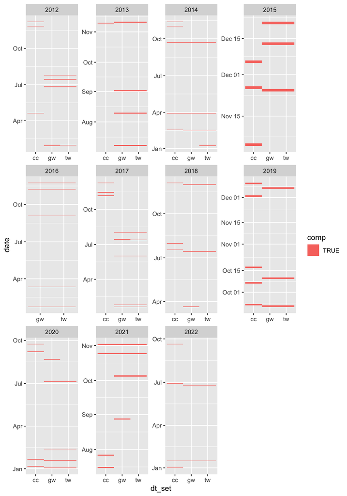

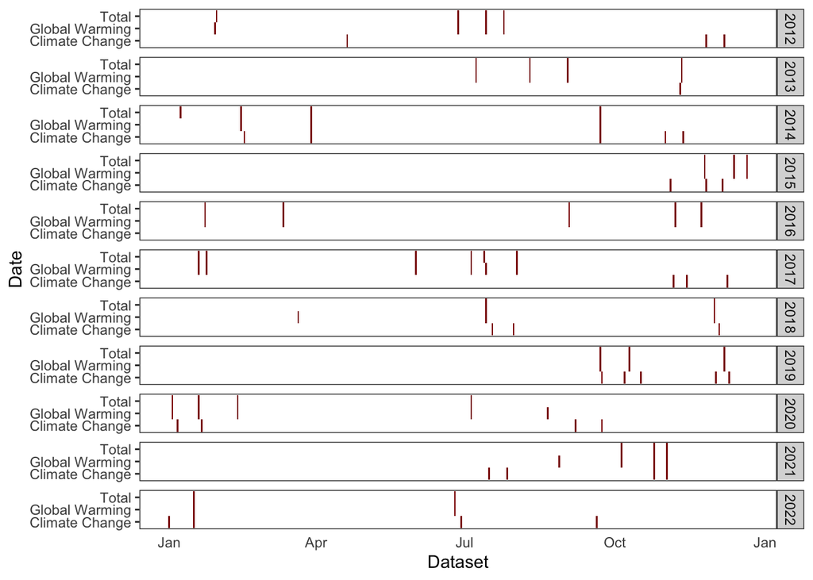